# DATA 607 Final Project

Santosh Manjrekar & Robert Lauto

12/12/2018

```r
suppressWarnings(suppressMessages(library('SnowballC')))
suppressWarnings(suppressMessages(library('tm')))
suppressWarnings(suppressMessages(library('twitteR')))
suppressWarnings(suppressMessages(library('syuzhet')))
suppressWarnings(suppressMessages(library('dplyr')))
suppressWarnings(suppressMessages(library('stringr')))
suppressWarnings(suppressMessages(library(ggplot2)))
suppressWarnings(suppressMessages(library(dplyr)))
suppressWarnings(suppressMessages(library(tidyr)))
suppressWarnings(suppressMessages(library('wordcloud')))
```

### Project description- Analyze the impact of twitter sentiment analysis on stock price

In this project we will try to assess if there is any relationship between twitter sentiment on stock price price variation.

### Team Members

Santosh Manjrekar, Robert Lauto

### Data Extraction

We used twitter API to extract the data. Mainly extracted the data for microsoft related twitter handles. Using the twitter API you can search and extract data for certain duration. We were able to get the data for last 10 days. Data was saved in the csv file per day. Please refer to the data extraction program on below github URl.

[GitHub location of Twitter Data Extraction](https://github.com/santoshmanjrekar/data607/blob/master/twitter_data_extraction.rmd)

Here is twitter dta extracted for a day.

```r
df_msft_twit_data = read.csv("C:\\santosh\\learning\\CUNY\\courses\\DATA607\\final-project\\msft\\data\\MSFT- 2018-12-11 -twitt-emotion-senti-data.csv")
head(df_msft_twit_data)
```

```
##    X
## 1  6
## 2 10
## 3 11
## 4 16
## 5 18
## 6 19
##                                                                                                                        text
## 1                              ShiSh ShridharDirector Business Strategy Retail Industrydiscusses whats really working and
## 2                              Microsoft does tell people Obscure technical blog posts most Windows users will never see c
## 3                                  I am justdone with usingWord\n\nYes I know Im well behind the great template wars of CHI
## 4                                             et al The Corporate Donors Behind a Republican PowerGrabOur democracy is bei
## 5 thanks for your most excellent customer service today Appreciate the swift response and resolution Have a great Christmas
## 6                                                                                             Cortana install Google Chrome
##   favorited favoriteCount  replyToSN             created truncated
```

[output cut: 41 more lines]

### Data Processing or tidying

Retwitted twits were filtered out. We used library syuzhet for sentiment analysis. This library gives different emotion score for the each tweet. Here is the sample of the emotion score

We grouped the data per day and average emotion score was calculated for the gathered twitts for the given day. So daily sentiment and emotion score was calculated.

Here is the sample

```r
df_msft_daily_summary = read.csv("C:\\santosh\\learning\\CUNY\\courses\\DATA607\\final-project\\msft\\MSFT-twitt-final-summary.csv")
head(df_msft_daily_summary)
```

```
##   X  data_date  net_sent  net_anger net_anticipation net_disgust
## 1 1 2018-12-03 0.6941333 0.07252359        0.4510613  0.05837264
## 2 1 2018-12-04 0.4753744 0.08402662        0.3356905  0.06405990
## 3 1 2018-12-06 0.4529504 0.10234987        0.3404700  0.07885117
## 4 1 2018-12-07 0.4471648 0.08405604        0.3288859  0.05937291
## 5 1 2018-12-10 0.3467890 0.12010008        0.2468724  0.07839867
## 6 1 2018-12-11 0.4900310 0.09164087        0.3498452  0.07678019
##     net_fear   net_joy net_sadness net_surprise net_trust net_negative
## 1 0.09316038 0.3873821  0.07900943   0.07783019 0.5047170    0.1650943
## 2 0.11148086 0.2583195  0.09525790   0.09941764 0.3677205    0.1880200
## 3 0.13211488 0.2443864  0.10339426   0.10913838 0.3650131    0.2036554
## 4 0.11607739 0.2308205  0.09673115   0.10540360 0.3689126    0.2008005
## 5 0.11342786 0.1801501  0.10091743   0.08006672 0.2952460    0.2410342
## 6 0.12817338 0.2681115  0.09721362   0.08421053 0.3894737    0.2198142
##   net_positive
## 1    0.9669811
## 2    0.7113145
## 3    0.6610966
## 4    0.6777852
## 5    0.5663053
## 6    0.7597523
```

### Data Analysis

Here is the graph of the Positive and Negative sentiments and emotion scores for each day. Positive sentiments and positive emotions show the same pattern..similary negative sentiment and negative emitions follow the same pattern.

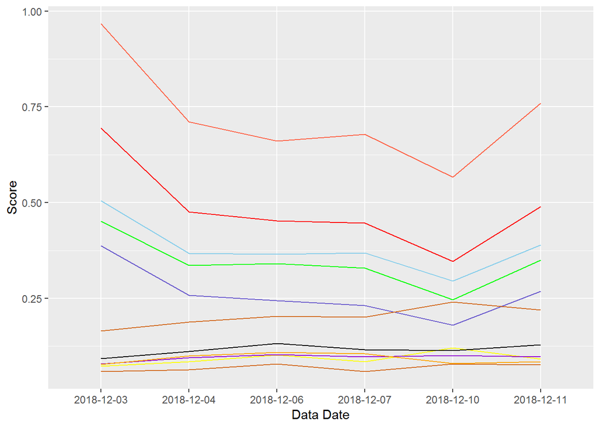

```r
ggplot(df_msft_daily_summary, aes(x = data_date)) +
  geom_line(aes(y = net_sent, group=1), colour="red") +
  geom_line(aes(y = net_anger, group=2), colour="yellow") +
  geom_line(aes(y = net_anticipation, group=3), colour="green") +
  geom_line(aes(y = net_disgust, group=4), colour="chocolate") +
  geom_line(aes(y = net_fear, group=5), colour="black") +
  geom_line(aes(y = net_joy, group=6), colour="slateblue") +
  geom_line(aes(y = net_sadness, group=7), colour="darkviolet") +
  geom_line(aes(y = net_surprise, group=8), colour="orange") +
  geom_line(aes(y = net_trust, group=9), colour="skyblue") +
  geom_line(aes(y = net_negative, group=10), colour="chocolate") +
  geom_line(aes(y = net_positive, group=11), colour="tomato") +

#geom_line(aes(y = Stock_Price, group=12), colour="darkviolet") +
 #geom_line(aes(y = No_Twitts, group=13), colour="red") +
 #geom_line(aes(y = Volume, group=14), colour="slateblue") +

  ylab(label="Score") +
  xlab("Data Date")
```

#### Positive sentiment word cloud

```r
df_positive <-df_msft_twit_data[df_msft_twit_data$sent.value > 3,]
nrow(df_positive)
```

```
## [1] 14
```

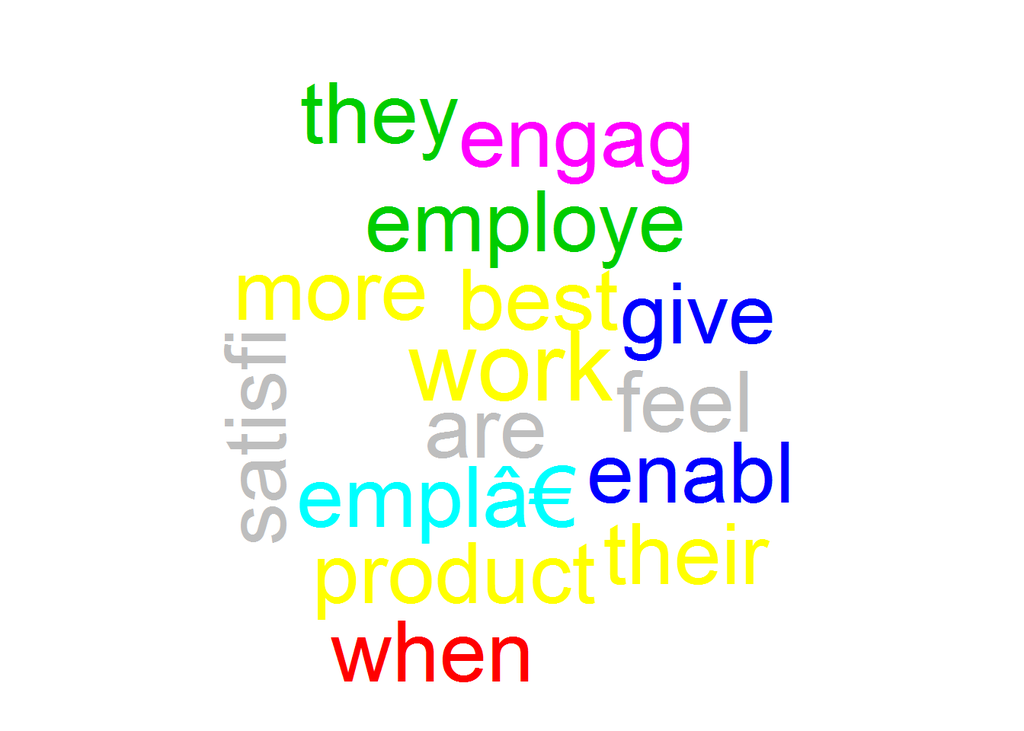

```r
#Show wordcloud

positive_corp <- Corpus(VectorSource(df_positive$text))

#positive_corp <- positive_corp %>% tm_map(content_transformer(PlainTextDocument))
positive_corp <- positive_corp%>% tm_map(content_transformer(removePunctuation))
positive_corp <- positive_corp %>% tm_map(content_transformer(tolower))
positive_corp <-tm_map(positive_corp,removeWords, c("the","and","that","this","was","with","for","your"))
positive_corp <- positive_corp %>% tm_map(content_transformer(removeNumbers))
positive_corp <- positive_corp %>% tm_map(content_transformer(stemDocument),  language = 'english')
#Stemming seems to truncate words

wordcloud(positive_corp, max.words = 75, random.order = FALSE, random.color = TRUE,colors=palette())
```

```r
#positive_corp_dtm <- positive_corp %>% DocumentTermMatrix()
#positive_corp_dtm
#positive_corp_freq <-  positive_corp_dtm %>% as.matrix() %>% colSums()
#length(positive_corp_freq) #Should be the same as term count, not document count.
#positive_corp_freq_ord <- positive_corp_freq %>% order(decreasing = TRUE)
```

#### Negative sentiment word cloud

Looks like many people not happy with windows’s updates.

```r
df_positive <-df_msft_twit_data[df_msft_twit_data$sent.value < -1,]
nrow(df_positive)
```

```
## [1] 34
```

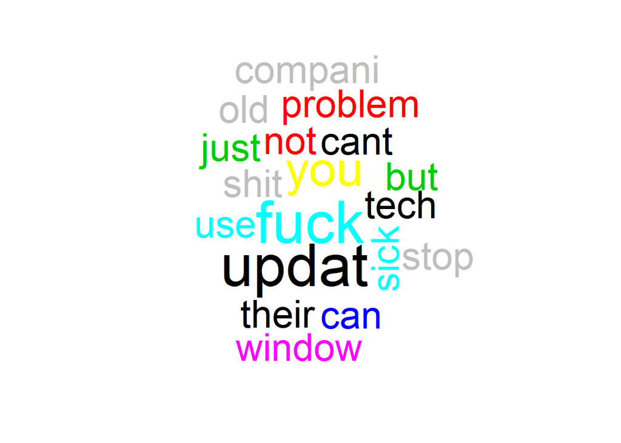

```r
#Show wordcloud

positive_corp <- Corpus(VectorSource(df_positive$text))

#positive_corp <- positive_corp %>% tm_map(content_transformer(PlainTextDocument))
positive_corp <- positive_corp%>% tm_map(content_transformer(removePunctuation))
positive_corp <- positive_corp %>% tm_map(content_transformer(tolower))
positive_corp <- positive_corp %>% tm_map(content_transformer(removeNumbers))
positive_corp <-tm_map(positive_corp,removeWords, c("the","and","that","this","was","with","for","your"))
positive_corp <- positive_corp %>% tm_map(content_transformer(stemDocument),  language = 'english')
#Stemming seems to truncate words

wordcloud(positive_corp, max.words = 75, random.order = FALSE, random.color = TRUE,colors=palette())
```

```r
#positive_corp_dtm <- positive_corp %>% DocumentTermMatrix()
#positive_corp_dtm
#positive_corp_freq <-  positive_corp_dtm %>% as.matrix() %>% colSums()
#length(positive_corp_freq) #Should be the same as term count, not document count.
#positive_corp_freq_ord <- positive_corp_freq %>% order(decreasing = TRUE)
```

### Twitter sentiment and stock price analysis

```r
msft <- read.csv('C:\\santosh\\learning\\CUNY\\courses\\DATA607\\final-project\\msft\\MSFT.csv')
msft$Date <- as.Date(msft$Date)
msft
```

```
##          Date   Open   High    Low  Close Adj.Close   Volume
## 1  2018-11-12 109.42 109.96 106.10 106.87  106.4103 33621800
## 2  2018-11-13 107.55 108.74 106.64 106.94  106.4800 35374600
## 3  2018-11-14 108.10 108.26 104.47 104.97  104.9700 39495100
## 4  2018-11-15 104.99 107.80 103.91 107.28  107.2800 38505200
## 5  2018-11-16 107.08 108.88 106.80 108.29  108.2900 33502100
## 6  2018-11-19 108.27 108.56 103.55 104.62  104.6200 44773900
## 7  2018-11-20 101.80 102.97  99.35 101.71  101.7100 64052500
## 8  2018-11-21 103.60 104.43 102.24 103.11  103.1100 28130600
## 9  2018-11-23 102.17 103.81 102.00 103.07  103.0700 13823100
## 10 2018-11-26 104.79 106.63 104.58 106.47  106.4700 32295500
## 11 2018-11-27 106.27 107.33 105.36 107.14  107.1400 29124500
## 12 2018-11-28 107.89 111.33 107.86 111.12  111.1200 46788500
## 13 2018-11-29 110.33 111.12 109.03 110.19  110.1900 28123200
## 14 2018-11-30 110.70 110.97 109.36 110.89  110.8900 33665600
## 15 2018-12-03 113.00 113.42 110.73 112.09  112.0900 34732800
## 16 2018-12-04 111.94 112.64 108.21 108.52  108.5200 45197000
## 17 2018-12-06 105.82 109.24 105.00 109.19  109.1900 49107400
## 18 2018-12-07 108.38 109.45 104.30 104.82  104.8200 45044900
## 19 2018-12-10 104.80 107.98 103.89 107.59  107.5900 40761400
## 20 2018-12-11 109.80 110.94 107.44 108.59  108.5900 42247103
```

```r
df_msft_daily_summary$data_date <- as.Date(df_msft_daily_summary$data_date)
stock_n_sent <- merge(df_msft_daily_summary, msft, by.x = 'data_date', by.y = 'Date')
microsoft_model <- lm(Close ~ net_sent, stock_n_sent)

ggplotRegression <- function (fit) {

require(ggplot2)

ggplot(fit$model, aes_string(x = names(fit$model)[2], y = names(fit$model)[1])) +
  geom_point() +
  stat_smooth(method = "lm", col = "red") +
  labs(title = paste("Adj R2 = ",signif(summary(fit)$adj.r.squared, 5),
                     "Intercept =",signif(fit$coef[[1]],5 ),
                     " Slope =",signif(fit$coef[[2]], 5),
                     " P =",signif(summary(fit)$coef[2,4], 5)))
}
cor(stock_n_sent$Close, stock_n_sent$net_sent)
```

```
## [1] 0.7378167
```

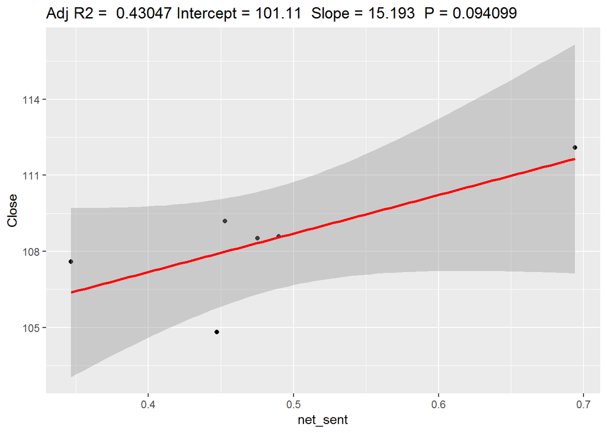

```r
ggplotRegression(microsoft_model)
```

```r
summary(microsoft_model)
```

```
##
## Call:
## lm(formula = Close ~ net_sent, data = stock_n_sent)
##
## Residuals:
##        1        2        3        4        5        6
##  0.43698  0.19057  1.20126 -3.08085  1.21415  0.03789
##
## Coefficients:
##             Estimate Std. Error t value Pr(>|t|)
## (Intercept)  101.107      3.444  29.359 8.01e-06 ***
## net_sent      15.193      6.950   2.186   0.0941 .
## ---
## Signif. codes:  0 '***' 0.001 '**' 0.01 '*' 0.05 '.' 0.1 ' ' 1
##
## Residual standard error: 1.777 on 4 degrees of freedom
## Multiple R-squared:  0.5444, Adjusted R-squared:  0.4305
## F-statistic: 4.779 on 1 and 4 DF,  p-value: 0.0941
```

### Conclusions

*There is not significant corelation between sentiment score and stock price.

*We would ahve gathered more data and that might have helped us for better analysis

*There are some other factors associated with stock price other than twitts and tat will be further study.

*This process was built keeping in mind to find the corelation of twitter sentiment and stock price but this process can be used to find out the response twitts for any new product launch and product reviews or similar use cases